# Capstone Project - Progress Report

Zach Olivier

3/31/2018

## Project Introduction

This document will review the progress I’ve made in the Data Science Capstone project.

We will focus on three main steps:

```
    - Reading in the data
    - Exploratory Data Analysis
    - Plans for modeling and application integration
```

## Part 1: Read in the Data

The first step to any data project is to read in and clean our data. In this project we have three large data sets that are composed on text from three major sources: Twitter, Blogs and News.

Below are the reading and cleaning steps taken to allow for deeper analysis.

[output not shown]

```
##       file_name file_size line_count sample_size
## 1   en_US.blogs  200.4242     899288       44964
## 2    en_US.news  196.2775    1010242       50512
## 3 en_US.twitter  159.3641    2360148      118007
```

```r
set.seed(23)

# clean twitter data (sample)
twitter_df <- sample_frac(twitter, .01) %>%
        tibble::rownames_to_column(., var = "line_id") %>%
        rename(., text = X1) %>%
        mutate(text = cleanText(text),
               source = "twitter")

# clean blogs data (sample)
blogs_df <- sample_frac(blogs, .01) %>%
        tibble::rownames_to_column(., var = "line_id") %>%
        rename(., text = X1) %>%
        mutate(text = cleanText(text),
               source = "blogs")

# clean news data (sample)
news_df <- sample_frac(news, .01) %>%
        tibble::rownames_to_column(., var = "line_id") %>%
        rename(., text= X1) %>%
        mutate(text = cleanText(text),
               source = "news")

# combine all datasets to analyze different tokenization
token_df <- bind_rows(twitter_df, blogs_df, news_df)

head(token_df, 5)
```

```
## # A tibble: 5 x 3
##   line_id text                                                      source
##   <chr>   <chr>                                                     <chr>
## 1 1       hahaha yeah im sure thats how it happened                 twitt…
## 2 2       im never naming my child   my  year old sister            twitt…
## 3 3       " verrado finished lots sold   per ff  dmb development s… twitt…
## 4 4       i think someone has to be listening to you for it to be … twitt…
## 5 5       having so much anxiety you get sick                       twitt…
```

```r
unique(token_df$source)
```

```
## [1] "twitter" "blogs"   "news"
```

## Part 2: Exploratory Analysis

Now that we have a cleaned data frame with all sources together - we are ready to begin our analysis.

I focused on analyzing term frequency and term frequency / inverse document frequency by various n-grams to see which words or string of words are the most impactful in each data set.

Results are listed below:

[figure not shown]

[figure not shown]

```
## # A tibble: 86,790 x 6
##    word     source  count       tf   idf   tf_idf
##    <chr>    <chr>   <int>    <dbl> <dbl>    <dbl>
##  1 rt       twitter   898 0.00306  0.405 0.00124
##  2 lol      twitter   702 0.00239  0.405 0.000970
##  3 congrats twitter   105 0.000358 1.10  0.000393
##  4 haha     twitter   235 0.000801 0.405 0.000325
##  5 dm       twitter    57 0.000194 1.10  0.000213
##  6 ppl      twitter    57 0.000194 1.10  0.000213
##  7 ur       twitter   153 0.000522 0.405 0.000211
##  8 wanna    twitter   150 0.000511 0.405 0.000207
##  9 thx      twitter    48 0.000164 1.10  0.000180
## 10 omg      twitter   116 0.000395 0.405 0.000160
## # ... with 86,780 more rows
```

[figure not shown]

[figure not shown]

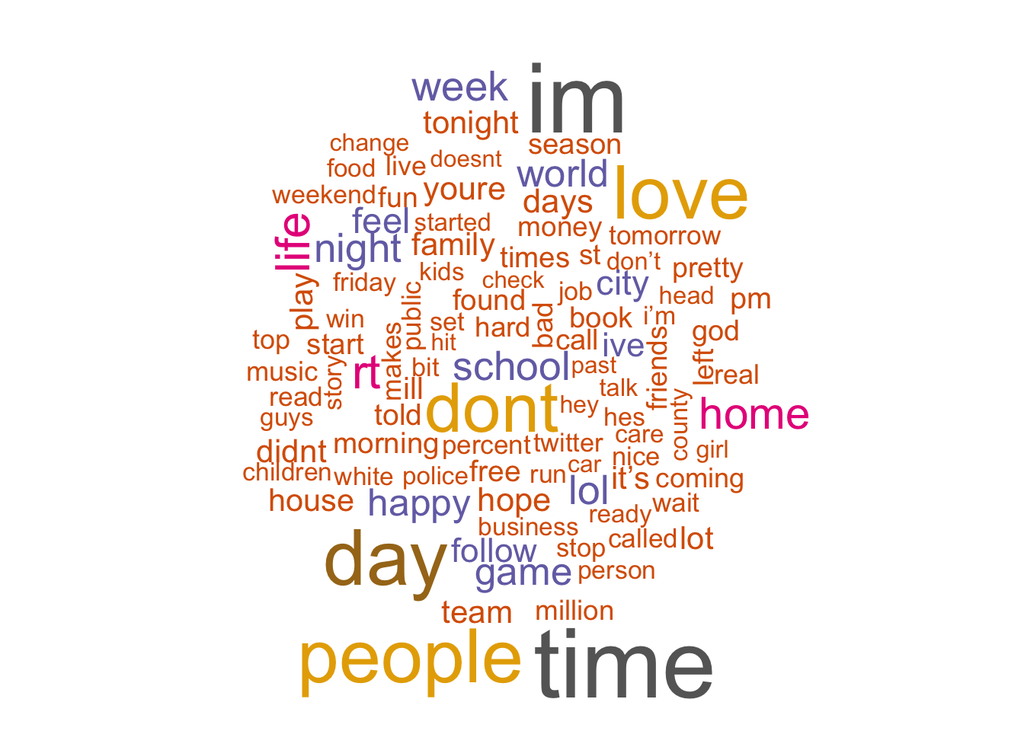

## Part 3: Plans for Modeling

The next steps for this project including building a predictive model and developing an online data project. I would like to explore storing this data and processing these text values with parallel computing.

It is also apparent that additional cleaning steps will need to be taken to remove or account for more “text message” wording that is not directly filtered out currently.